# Importance of Running Back vs Offensive Line for Run Game

### James Boggs

American Football, specifically the National Football League (NFL) is the most watched sport in the united states. If you aren't familiar with how the game is played you can read about the rules [here](https://en.wikipedia.org/wiki/American_football_rules). In this tutorial we are going to be looking at two positions in particular, running backs and offensive linemen. If you are unfamiliar with the positions you can read about them [here](https://en.wikipedia.org/wiki/American_football_positions). Running Backs are a position that gets a lot of spotlight in the NFL, the top performing ones will be known by most fans of the game. However, in order for a running back to be successful, they rely on a lot of other player, primarily, the offensive line needs to do a good job of blocking to create holes in the defense for the running back to run through. The goal of this tutorial is to investigate how much of a productive run game is due to a good running back vs good offensive linemen, and further to look into how to predict how good of a run game a team will have based on the players they have in these positions.

## Where is the Data Doming From

To do the analysis in this tutorial we are going to look at data on the game stats of individual players as well as teams and also look at player salary data. Player statistics are gotten from the website [Football Outsider](https://www.footballoutsiders.com/) A database for player statistics. This website does require an account to access it's data but making an account is completely free and only requires email verification. Team statistics will be gotten from the website [espn.com](https://www.espn.com/nfl/stats/team/_/season/2020/seasontype/2). Lastly, Data on player pay will be collected from the website [Spotrac](https://www.spotrac.com/nfl/positional/). In order to access the more that the past three years of data on spotrac requires a paid account, if you don't want to pay for an account then just do analysis on the past 3 years only.

## Scraping the Data

The code is written in python 3 and makes use of these imported libraries: [pandas](https://pandas.pydata.org/docs/), [requests](https://docs.python-requests.org/en/master/index.html), [BeautifulSoup](https://beautiful-soup-4.readthedocs.io/en/latest/), [matplotlib](https://matplotlib.org/), [numpy](https://numpy.org/doc/stable/), [re](https://docs.python.org/3/library/re.html), [statsmodel](https://www.statsmodels.org/stable/index.html), and [scikit-learn](https://scikit-learn.org/stable/index.html). The puropose of each of these will be explained as they get used.

```python
import pandas as pd
from bs4 import BeautifulSoup
import requests
import pandas as pd
import numpy as np
import re
from matplotlib import pyplot
import statsmodels.api as sm
from sklearn.neighbors import KNeighborsRegressor
from sklearn.model_selection import train_test_split
from sklearn import metrics
```

In order to access data from all the teams easily, we prepared a csv file with team names, cities, and abbreviations, as well as the old cities/names of teams that moved or changed name, also a range for what years to get data from is specified. The information about the teams is stored in a pandas [dataframe](https://pandas.pydata.org/pandas-docs/stable/reference/api/pandas.DataFrame.html), which is a data structure for storing tabular data.

```python
# load data from csv file into a pandas dataframe
teams = pd.read_csv('teams.csv')

# create a reange of years to collect data from
years = range(2011,2021)
```

This function will be used later to help fix some of the weird column labels we get in dataframes when scraping data from some websites.

```python
# turn multi index column labels with 2 values into a sigle index
# input is the dataframe to be changed, and wether or not to include the first value in the multi index in the new label
def remove_muli_index(table, merge=False):
    # fill up an array with all the new column labels
    new_columns = []
    for c in table.columns:
        if merge:
            new_columns.append(c[0] + " " + c[1])
        else:
            new_columns.append(c[1])

    # assign the new column labels to the given dataframe
    table.columns = new_columns
```

### Player Stats

First we will scrape data on stats for running backs and offensive lines from the site [Football Outsider](https://www.footballoutsiders.com/). To do this we will use the [requests](https://docs.python-requests.org/en/master/index.html) library to make http requests from our code. Then we will use the [BeautifulSoup](https://beautiful-soup-4.readthedocs.io/en/latest/) library to extract the data we want from the html that was returned by the websites. The Football Outsider site requires we log in to access its data so first create an account then we will have to login to this account using the request module before requesting the data. In order to log in we need to see what data the site expects to receive with a post request for logging in. This is all shown down below but if you are curious how this is found from a site then here is how. Go to the website and inspect it, then fill out the username and password and login in, after that you can go to the network tab then click on payload in order to see what data was sent to the website.

[figure not shown]

```python
# your username and password for the site
username = 'your username'
password = 'your password'

# Prepare the data to log in including username and password along with some other fields the website expects.
payload1 = {
    'name': username,
    'pass': password,
    'form_build_id': 'form-N4HyLeL752hMNQ8pD4cKgiSVWackM45Y_Mglp4uSjkg',
    'form_id': 'user_login_form',
    'op': 'Login'
}

# create a session using the request module, this will cook track of the login cookie and send it with
# subsequent requests so the site knows the session is logged in
session1 = requests.Session()

# log in to the site
session1.post('https://www.footballoutsiders.com/user/login?destination=home', data=payload1)
```

```
<Response [200]>
```

Now that the session is logged in we can get the data from the site. The data is requested from the session then processed by BeautifulSoup which lets us search for particular html tags. In this case we want to pull out all the tables because these are what is holding all the data. First we will get data on the offensive line. This is all stores in one table on the site so all we have to do is store the table in a pandas dataframe then rename some columns, remove a cumulative NFL entry in the table and add the year. Then just add together the dataframes from each year. The final result will be a table where each row is the stats on the offensive line for one team on a particular year.

```python
# create empty dataframe to accumulate data from each year
line_stats_table = pd.DataFrame()

# get the table for each year from the site
for year in years:
    # request the html from the site
    r = session1.get("https://www.footballoutsiders.com/stats/nfl/basic-offensive-line/" + str(year))

    # read the html and find the desired table with Beautiful soup
    root1 = BeautifulSoup( r.content )
    t = root1.find("table")

    # save the table into a pandas dataframe
    temp = pd.read_html(t.prettify())[0]

    # remove an empty column that gets created
    temp.drop([("PASS PROTECTION", "Unnamed: 15_level_1")], axis=1, inplace=True)

    # remove the final enty in the table which is a cumulative one for the whole NFL and doesn't represent an individual team
    temp.drop([32], axis=0, inplace = True)

    # rename the columns to be single index
    remove_muli_index(temp)

    # add a year column to the table
    temp["year"] = year

    # add the table for one year to the accumulated table
    line_stats_table = line_stats_table.append(temp)

# reset the index
line_stats_table = line_stats_table.reset_index().drop(["index"],axis=1)

# change the abbreviation for jacksonville so it matches whats in the teams table
line_stats_table.replace(['JAX'],'JAC', inplace=True)
```

```python
line_stats_table.sample(5)
```

|  | RK | Team | Adj. Line Yards | RB Yards | Power Success | Power Rank | Stuffed | Stuffed Rank | 2nd Level Yards | 2nd Level Rank | Open Field Yards | Open Field Rank | Rank | Sacks | Adjusted Sack Rate | year |
| --- | --- | --- | --- | --- | --- | --- | --- | --- | --- | --- | --- | --- | --- | --- | --- | --- |
| 301 | 14.0 | KC | 4.38 | 4.22 | 51% | 32 | 18% | 20 | 1.32 | 7 | 0.48 | 30 | 4 | 24 | 4.5% | 2020 |
| 266 | 11.0 | DEN | 4.45 | 4.24 | 69% | 8 | 15% | 3 | 1.18 | 17 | 0.61 | 23 | 25 | 41 | 8.1% | 2019 |
| 199 | 8.0 | ATL | 4.35 | 4.25 | 64% | 17 | 21% | 20 | 1.25 | 6 | 0.85 | 10 | 8 | 24 | 4.8% | 2017 |
| 210 | 19.0 | MIN | 3.96 | 3.98 | 67% | 10 | 21% | 19 | 1.11 | 17 | 0.77 | 13 | 6 | 27 | 4.4% | 2017 |
| 281 | 26.0 | CIN | 3.90 | 3.95 | 67% | 13 | 22% | 29 | 1.10 | 23 | 0.70 | 19 | 20 | 48 | 7.3% | 2019 |

Next we do the same thing for the running back data. The only difference is that running back data is for individual players and is split among multiple tables on the website. The two we care about are the one for the one for over 100 rushes and 20-99 rushes which hold data about the running statistics of the running backs. The over 100 rushes table has some more columns that the 20-99 table so we remove those then combine them together. The final result will be a table where each row is the stats on one running back for a particular year.

```python
# create empty dataframe to accumulate data from each year
rb_stats_table = pd.DataFrame()

# get the tables for each year from the site
for year in years:
    # request the html from the site
    r = session1.get("https://www.footballoutsiders.com/stats/nfl/rb/" + str(year))

    # read the html and find the desired tables with Beautiful soup
    root1 = BeautifulSoup( r.content )
    t = root1.find_all("table")

    # save the two tables into a pandas dataframes
    temp1 = pd.read_html(t[0].prettify())[0]
    temp2 = pd.read_html(t[1].prettify())[0]

    # remove the extra columns from the over 100 rushes table
    for name in ["DYAR", "YAR", "DVOA", "VOA", "EYds", "Suc Rate"]:
        temp1.drop([name], axis=1, inplace=True)
        temp1.rename(columns={name + ".1":name}, inplace=True)

    # combine the two tables into one for the year
    temp1 = temp1.append(temp2)

    #drop rows that contain any value in the list
    temp1 = temp1[temp1.Team.isin(["2TM", "3TM"]) == False]

    # add a year column to the table
    temp1["year"] = year

    # add the table for one year to the accumulated table
    rb_stats_table = rb_stats_table.append(temp1)

# reset the index
rb_stats_table = rb_stats_table.reset_index().drop(["index"],axis=1)

# change the abbreviation for jacksonville so it matches whats in the teams table
rb_stats_table.replace(['JAX'],'JAC', inplace=True)
```

```python
rb_stats_table.sample(5)
```

|  | Player | Team | DYAR | YAR | DVOA | VOA | Runs | Yards | EYds | TD | FUM | Suc Rate | year |
| --- | --- | --- | --- | --- | --- | --- | --- | --- | --- | --- | --- | --- | --- |
| 845 | N. Chubb | CLE | 276 | 257 | 25.5% | 23.2% | 191 | 1067 | 1145 | 12 | 1 | 52% | 2020 |
| 891 | A. Morris | NYG | 61 | 35 | 19.4% | 7.4% | 55 | 238 | 285 | 1 | 0 | NaN | 2020 |
| 74 | T. Hightower | WAS | -6 | 9 | -10.4% | -5.9% | 84 | 321 | 275 | 1 | 0 | NaN | 2011 |
| 560 | D. Harris | SF | -31 | -32 | -28.1% | -28.9% | 38 | 144 | 85 | 0 | 1 | NaN | 2016 |
| 788 | B. Snell | PIT | -14 | 6 | -11.7% | -7.3% | 108 | 426 | 364 | 2 | 1 | 49% | 2019 |

### Player Pay

Now we collect player payment data from the site [Spotrac](https://www.spotrac.com/nfl/positional/). This site also need to be logged in to in order to access all the data so we will use the same process as before for this.

```python
# your username and password for the site
username = 'your username'
password = 'your password'

# Prepare the data to log in including username and password along with some other fields the website expects.
payload2 = {
    'redirect': 'signin',
    'email': username,
    'password': password,
}

# create a session using the request module, this will cook track of the login cookie and send it with
# subsequent requests so the site knows the session is logged in
session2 = requests.Session()

# log in to the site
session2.post('https://www.spotrac.com/signin/submit/', data=payload2)
```

```
<Response [200]>
```

The process for getting the pay for offensive linemen and running backs is exactly the same so we can create on function to use for both. The data is gathered on by year and by team, when choosing the team some work needs to be done to ensure the right url is used for teams that have changed their name or location during the period we are looking at. Once the table is read we clean up some columns we don't want, rename some for convenience, and split up player name and team which are stored together in one column on the site. We also change the form of the player names to be first letter of first name then last name so it matches with the player stat data we collected earlier. We then Store the data in two dataframes, one for individual players and one that is the sum of the amount spent total by a team on that position. The final result is four tables, a table where each row is an individual player for a particular year and a table where each row is one team for a particular year, one of each of these tables for running backs and offensive linemen.

```python
# get pay data for a given position and return a team table and an individual table
def scrape_pay_data(position):

    # create empty dataframe to accumulate data from each year
    individual_table = pd.DataFrame()
    team_table = pd.DataFrame()

    # go through each year and each team and get the table for them
    for year in years:
        for i in range(teams.shape[0]):
            # ensure that the team name is the correct one for that year

            # set name and city to the current one
            city = teams["city"].iat[i]
            name = teams["name"].iat[i]
            # check if team has an old name that they used during this year
            if (not teams["switch year"].isnull().iat[i]) and year < teams["switch year"].iat[i]:
                # set name city to the old ones
                city = teams["old city"].iat[i]
                name = teams["old name"].iat[i]

            # request the html from the site
            r = session2.get('https://www.spotrac.com/nfl/rankings/' + str(year) +
                             '/contract-average-cap-pct/' + city + '-' + name + '/' + position + '/')

            # read the html and find the desired table with Beautiful soup
            root1 = BeautifulSoup( r.content )
            t = root1.find("table")

            # save the table into a pandas dataframe
            temp = pd.read_html(t.prettify())[0]

            # delete some columns that aren't needed
            temp.drop(["Unnamed: 0"], axis=1, inplace=True)
            temp.drop(["Signed Year"], axis=1, inplace=True)

            # rename a columns for convenience
            temp.rename(columns={"contract average cap pct":"cap %"}, inplace=True)


            # split up the columns that contains player name and team into two columns

            # create a column of the player name and team in a list split up by whitespace
            temp["name and team"] = temp["Player"].str.split()
            temp["team"] = ""

            # go through each row
            for j in range(temp.shape[0]):
                # set the team column to the last item in the name and team list which is the team
                temp.at[j, "team"] = temp.at[j, "name and team"][-1]

                # set the player column to the First letter of the first name plus the last name
                temp.at[j, "Player"] = temp.at[j,"name and team"][0][0] + ". " + temp.at[j,"name and team"][1]
            temp.drop(["name and team"], axis=1, inplace=True)

            # add a year column to the table
            temp["year"] = year
            # convert the cap % column to type float
            temp["cap %"] = temp["cap %"].replace('[\%,]', '', regex=True).astype(float)

            # add the table for one year to the accumulated individual table
            individual_table = individual_table.append(temp.copy())

            # temporarily remove year column so it doesn't get summed
            temp.drop(["year"], axis=1, inplace=True)

            # add a column for number of players
            temp["number"] = 1

            # sum the player pay for the current team
            temp = temp.groupby(['team']).sum()

            # add back the year column
            temp["year"] = year

            # add the table for one year to the accumulated team table
            team_table = team_table.append(temp.reset_index())

    # reset the index
    individual_table = individual_table.reset_index().drop(["index"],axis=1)

    return individual_table, team_table

# call the function for offensive linemen and running backs
line_pay_table, team_line_pay_table = scrape_pay_data("offensive-line")
rb_pay_table, team_rb_pay_table = scrape_pay_data("running-back")
```

```python
line_pay_table.sample(5)
```

|  | Player | POS | cap % | team | year |
| --- | --- | --- | --- | --- | --- |
| 2928 | J. Veldheer | RT | 1.86 | GB | 2019 |
| 3063 | W. Hernandez | G | 0.99 | NYG | 2019 |
| 1740 | C. Toner | G | 0.41 | ARI | 2016 |
| 3067 | N. Gates | G | 0.30 | NYG | 2019 |
| 2614 | A. Wylie | G | 0.30 | KC | 2018 |

```python
team_line_pay_table.sample(5)
```

|  | team | cap % | number | year |
| --- | --- | --- | --- | --- |
| 0 | JAC | 14.49 | 10 | 2011 |
| 0 | CLE | 21.58 | 9 | 2018 |
| 0 | CAR | 15.03 | 15 | 2014 |
| 0 | NYG | 19.27 | 10 | 2019 |
| 0 | DET | 17.19 | 10 | 2018 |

### Team Stats

Finally, we collect data on team stats from [espn.com](https://www.espn.com/nfl/stats/team/_/season/2020/seasontype/2). This site does not need to be logged in to in order to access the data so the process is a bit simpler to get the html. We just need to get the table for each year from the website and rename some columns. However, the data on the website gets divided into two tables during this process so they need to be put back together. After that we need to work with the team name column so that it can be matched up with the teams in the teams table.

```python
# create empty dataframe to accumulate data from each year
team_stats_table = pd.DataFrame()

for year in years:
    # request the html from the site
    r = requests.get('https://www.espn.com/nfl/stats/team/_/season/' + str(year) + '/seasontype/2')

    # read the html and find the desired tables with Beautiful soup
    root1 = BeautifulSoup( r.content )
    tables = root1.find_all("table")

    # save the first table into a pandas dataframe, moving the first entry from the column label back into the data
    temp = pd.read_html(tables[0].prettify())[0].T.reset_index().T.reset_index(drop=True)

    # rename the column
    temp.columns = ['team']

    # save the second table into a pandas dataframe
    temp2 = pd.read_html(tables[1].prettify())[0]

    # rename the columns to be single index
    remove_muli_index(temp2, merge=True)

    # join the two columns back together
    temp = temp.join(temp2, how='outer')

    # rename the games played column
    temp.rename(columns={'Unnamed: 0_level_0 GP': 'GP'}, inplace=True)

    # add a year column to the table
    temp["year"] = year
    team_stats_table = team_stats_table.append(temp)

# reset the index
team_stats_table.reset_index(inplace=True)
team_stats_table.drop(["index"], axis=1, inplace=True)

# change the name of washington so it is consistent
team_stats_table['team'] = team_stats_table['team'].replace(['Washington', 'Washington Redskins'],'Washington football-team')

# convert the city and team name into jsut the team name
team_stats_table["city and name"] = team_stats_table['team'].str.split()
team_stats_table["team"] = ""
for i in range(team_stats_table.shape[0]):
    team_stats_table.at[i, "team"] = team_stats_table.at[i, "city and name"][-1].lower()
team_stats_table.drop(["city and name"], axis=1, inplace=True)

# add in the team abbreviation by joining it with part of the teams table
team_stats_table = team_stats_table.set_index('team').join(teams[["abbreviation", "name"]].set_index('name'),how="inner")
team_stats_table = team_stats_table.reset_index().drop(["index"], axis=1).rename(columns={"abbreviation":"team"})
```

## Data Visualization and Analysis

Now that all the data is collected we can begin analyzing it. In order to determine the impact of the running back vs offensive line on the running game of a team, we need a way to evaluate the quality of the linemen and the running back as well as how well a teams run game is. Evaluating the quality of these two positions is the biggest problem. The reason why we are investigating this question in the place is that it's hard to evaluate ones performance independent of the other. The way we will attempt to do this first is by looking at how much players are paid. Coaches and scouts spend lots of time looking at game film to evaluate individual players performances and will pay the ones who they think are the best more. So looking at player pay gives us a way to measure something that's at least correlated with how good an individual player is. For evaluating how good a teams run game we will first use the number of rushing yards they produced during a season. With these to measures we can make a basis first visualization which we can later go on to refine.

### Preparing the Data

in order to make the proposed plot we need to combine data from the team pay tables as well as the team stat tables.

```python
# merge the team_stats_table with the team_line_pay_table and the team_rb_pay_table
team_table = pd.merge(team_stats_table, team_line_pay_table.replace(['OAK'],'LV').replace(['STL'], 'LAR').replace(['SD'], 'LAC'), how='outer', on=['year', 'team'])
team_table.rename(columns = {'cap %':'line cap %', 'number':'line number'}, inplace=True)
team_table = pd.merge(team_table, team_rb_pay_table.replace(['OAK'],'LV').replace(['STL'], 'LAR').replace(['SD'], 'LAC'), how='outer', on=['year', 'team'])
team_table.rename(columns = {'cap %':'rb cap %', 'number':'rb number'}, inplace=True)
```

#### Note on Player Pay

In the NFL teams have a [salary cap](https://en.wikipedia.org/wiki/Salary_cap#National_Football_League), which is the maximum amount the team can spend on all of their players. This salary cap increases fairly quickly over time which means players tend to get paid more as time passes. To account for this and evenly compare teams from different years, we are using percent of cap space as the measures of a players salary so that their salary is normalized with respect to the salary cap.

### Graphing Total Rushing Yards Vs. % of Cap Space Spent on Running Backs/Offensive Line

We can now create a scatterplot for each position of these two measurements along with a line of best fit which we can make using the close form linear algebra solution and the math library [numpy](https://numpy.org/doc/stable/) to help visualize and measure what their relationship is.

```python
# graphs the given two columns of the given table with the given title as a scatterplot with line of best fit
# return the prepared X and Y matrix for analysis
def graph_with_line(table, xcol, ycol, xtitle, ytitle):

    # set up the aesthetics, title, and labels for the graph
    fig= pyplot.figure(figsize=(12,6))
    pyplot.xticks(fontsize=14)
    pyplot.xlabel(xtitle, fontsize=20)
    pyplot.yticks(fontsize=14)
    pyplot.ylabel(ytitle, fontsize=20)
    pyplot.title(xtitle + " Vs. " + ytitle, fontsize=24)

    # x variable vs the y variable
    pyplot.plot(table[xcol], table[ycol], 'o')

    # create a line of best fit

    # set up the x and y from the data
    X = np.zeros((table.shape[0],2))
    Y = np.zeros(table.shape[0])
    for i in range(table.shape[0]):
        X[i][0] = 1
        X[i][1] = table[xcol].iat[i]
        Y[i] = table[ycol].iat[i]

    # solve using the close form equation
    params = np.linalg.solve(X.T.dot(X), X.T.dot(Y))

    # plot the line of best fit
    pyplot.plot(pyplot.xticks()[0],pyplot.xticks()[0] * params[1] + params[0], label='Line of Best Fit')
    pyplot.legend(loc="upper left")

    return X, Y
```

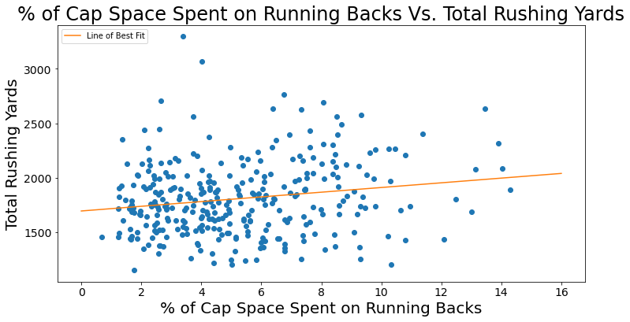

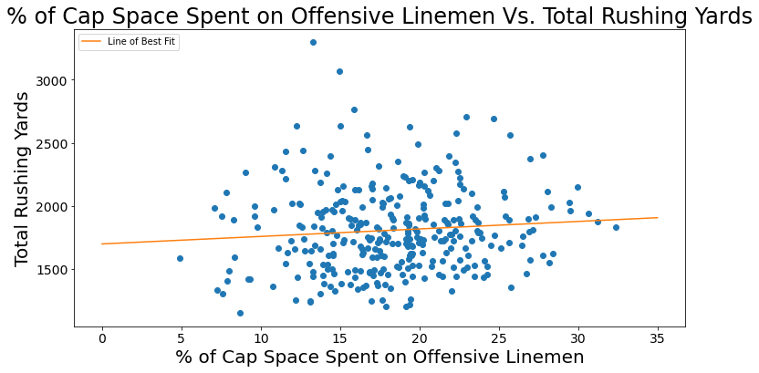

```python
X_rb, Y_rb = graph_with_line(team_table, "rb cap %", "Rushing YDS", "% of Cap Space Spent on Running Backs", "Total Rushing Yards")
X_line, Y_line = graph_with_line(team_table, "line cap %", "Rushing YDS", "% of Cap Space Spent on Offensive Linemen", "Total Rushing Yards")
```

### Analysis of Total Rushing Yards Vs. % of Cap Space Spent on Running Backs/Offensive Line

stat tests for the lines of best fit usind the statistics library [statsmodel](https://www.statsmodels.org/stable/index.html)

```python
# run statistics tests on the linear regression model using statsmodel
print(sm.OLS(Y_rb, X_rb).fit().summary())
print(sm.OLS(Y_line, X_line).fit().summary())
```

```
                            OLS Regression Results
==============================================================================
Dep. Variable:                      y   R-squared:                       0.032
Model:                            OLS   Adj. R-squared:                  0.029
Method:                 Least Squares   F-statistic:                     10.58
Date:                Sun, 19 Dec 2021   Prob (F-statistic):            0.00126
Time:                        20:41:36   Log-Likelihood:                -2307.5
No. Observations:                 320   AIC:                             4619.
Df Residuals:                     318   BIC:                             4627.
Df Model:                           1
Covariance Type:            nonrobust
==============================================================================
                 coef    std err          t      P>|t|      [0.025      0.975]
------------------------------------------------------------------------------
const       1697.2614     39.106     43.402      0.000    1620.323    1774.200
x1            21.5177      6.615      3.253      0.001       8.504      34.531
==============================================================================
Omnibus:                       40.746   Durbin-Watson:                   1.327
Prob(Omnibus):                  0.000   Jarque-Bera (JB):               65.057
Skew:                           0.774   Prob(JB):                     7.46e-15
Kurtosis:                       4.576   Cond. No.                         12.9
==============================================================================

Notes:
[1] Standard Errors assume that the covariance matrix of the errors is correctly specified.
                            OLS Regression Results
==============================================================================
Dep. Variable:                      y   R-squared:                       0.008
Model:                            OLS   Adj. R-squared:                  0.004
Method:                 Least Squares   F-statistic:                     2.404
Date:                Sun, 19 Dec 2021   Prob (F-statistic):              0.122
Time:                        20:41:36   Log-Likelihood:                -2311.6
No. Observations:                 320   AIC:                             4627.
Df Residuals:                     318   BIC:                             4635.
Df Model:                           1
Covariance Type:            nonrobust
==============================================================================
                 coef    std err          t      P>|t|      [0.025      0.975]
------------------------------------------------------------------------------
const       1700.9538     72.474     23.470      0.000    1558.364    1843.543
x1             5.9316      3.826      1.550      0.122      -1.595      13.458
==============================================================================
Omnibus:                       45.235   Durbin-Watson:                   1.260
Prob(Omnibus):                  0.000   Jarque-Bera (JB):               68.149
Skew:                           0.879   Prob(JB):                     1.59e-15
Kurtosis:                       4.422   Cond. No.                         74.0
==============================================================================

Notes:
[1] Standard Errors assume that the covariance matrix of the errors is correctly specified.
```

The First thing you may notice just by looking at the graph or at the low R squared value in the stat test is that the variables are not highly correlated with each other. This is not surprising though. There are lots of other factors that go into how many rushing yards a team gets in a year such as the number of run plays the team runs, how good the play calls are, what quality of opponents the team faces among many more. Among all these factors we wouldn't expect just one measure to determine too much about how many rushing yards the team gets. Looking further into the R squared value we can see that it is higher for the running back pay variable, this would seem to suggest that the running back's skill has more impact on the run game of a team than the skill of the offensive line. However this result is not very conclusive yet, Looking at the P values for our two variables, the running back pay seems pretty significant, while the offensive line pay is a lot less statistically meaningful. In order to get a more sure result we will try to refine our model by trying to account for some more factors.

### Refining the Variables

First looking at total rushing yards there are a couple ways that come to mind to improve this measure for how good the run game for a team is. One is that this measure includes rushing yards by the quarterback. We are only interested in the yards that running backs produce so we want to make sure those yards are not included. Furthermore the amount of rushing yards is dependent on how many runs a team attempts, to control for this we can instead look at the number of yards per attempt that a running back gets. In order to look at just the yards from running backs we can look at individual running backs yards instead of the whole team, this also gives us data on the number of runs since that is included in our individual stat table.

### Preparing the Data

In order to make this new graph we need to combine data from the individual running back stat, individual running back pay, and team offensive line pay table. First we need to match up running backs from the pay table and the stat table. Next we need to assign each of them a team offensive line pay value for their team.

```python
print("Running backs in stats table: " + str(rb_stats_table.shape[0]))
print("Running backs in pay table: " + str(rb_pay_table.shape[0]))
```

```
Running backs in stats table: 938
Running backs in pay table: 1493
```

There are significantly more running backs in the pay table than in the stats table. This makes sense since the stats table only has entries for running backs who had 20 or more runs during the season while the pay table has the pay for every backup running back who might not have played a single snap during a season. Ideally all the running backs in the stats table would be in the pay table but we shall see what happens when we combine them.

before merging we want to make sure that each players name is unique because there could be two players playing on the same tame on the same year with the same last name and first letter of their first name

```python
# check for duplicate names in stats table
rb_stats_table[rb_stats_table[["Player", "year", "Team"]].duplicated()]
```

|  | Player | Team | DYAR | YAR | DVOA | VOA | Runs | Yards | EYds | TD | FUM | Suc Rate | year |
| --- | --- | --- | --- | --- | --- | --- | --- | --- | --- | --- | --- | --- | --- |
| 830 | D. Williams | KC | -15 | -13 | -15.7% | -14.6% | 41 | 141 | 160 | 3 | 1 | NaN | 2019 |
| 937 | D. Johnson | HOU | -117 | -86 | -45.1% | -35.5% | 77 | 235 | 85 | 1 | 2 | NaN | 2020 |

```python
# check for duplicate names in pay table
rb_pay_table[rb_pay_table[["Player", "year", "team"]].duplicated()]
```

|  | Player | POS | cap % | team | year |
| --- | --- | --- | --- | --- | --- |
| 210 | K. Toston | RB | 0.39 | JAC | 2012 |
| 1118 | D. Williams | RB | 0.32 | KC | 2018 |
| 1263 | D. Williams | RB | 0.31 | KC | 2019 |
| 1390 | D. Johnson | RB | 2.63 | HOU | 2020 |
| 1409 | D. Williams | RB | 0.29 | KC | 2020 |

There are in fact some duplicate names, there are few enough so that we can go through and deal with them manually. Looking it up there was Damien Williams and Darrel Williams on the chiefs in 2019 and David Johnson and Duke Johnson on the texans in 2020 the one with more runs was also the one who was paid more in both cases so we can add numbers to correctly pair them up.

```python
# find both D. Williams on the chiefs in 2019 in the stats table
print(rb_stats_table[(rb_stats_table["Player"] == "D. Williams") & (rb_stats_table["Team"] == "KC") & (rb_stats_table["year"] == 2019)])

# find both D. Williams on the chiefs in 2019 in the pay table
print(rb_pay_table[(rb_pay_table["Player"] == "D. Williams") & (rb_pay_table["team"] == "KC") & (rb_pay_table["year"] == 2019)])

# rename the second D. Williams
rb_stats_table.iat[830, 0] = "D. Williams 2"

# rename the second D. Williams
rb_pay_table.iat[1263, 0] = "D. Williams 2"


# find both D. Johnsons on the texans in 2020 in the stats table
print(rb_stats_table[(rb_stats_table["Player"] == "D. Johnson") & (rb_stats_table["Team"] == "HOU") & (rb_stats_table["year"] == 2020)])

# find both D. Johnsons on the texans in 2020 in the pay table
print(rb_pay_table[(rb_pay_table["Player"] == "D. Johnson") & (rb_pay_table["team"] == "HOU") & (rb_pay_table["year"] == 2020)])

# rename the second D. Williams
rb_stats_table.iat[937, 0] = "D. Johnson 2"

# rename the second D. Williams
rb_pay_table.iat[1390, 0] = "D. Johnson 2"
```

```
          Player Team  DYAR  YAR    DVOA     VOA  Runs  Yards  EYds  TD  FUM  \
781  D. Williams   KC     8   23   -6.8%   -3.7%   111    500   412   5    1
830  D. Williams   KC   -15  -13  -15.7%  -14.6%    41    141   160   3    1

    Suc Rate  year
781      50%  2019
830      NaN  2019
           Player POS  cap % team  year
1260  D. Williams  RB   1.35   KC  2019
1263  D. Williams  RB   0.31   KC  2019
         Player Team  DYAR  YAR    DVOA     VOA  Runs  Yards  EYds  TD  FUM  \
865  D. Johnson  HOU    71   85    2.2%    4.2%   147    691   686   6    0
937  D. Johnson  HOU  -117  -86  -45.1%  -35.5%    77    235    85   1    2

    Suc Rate  year
865      46%  2020
937      NaN  2020
          Player POS  cap % team  year
1389  D. Johnson  RB   6.56  HOU  2020
1390  D. Johnson  RB   2.63  HOU  2020
```

Now that those two are dealt with there are only duplicates in the pay table

```python
# check for duplicate names in pay table
rb_pay_table[rb_pay_table[["Player", "year", "team"]].duplicated()]
```

|  | Player | POS | cap % | team | year |
| --- | --- | --- | --- | --- | --- |
| 210 | K. Toston | RB | 0.39 | JAC | 2012 |
| 1118 | D. Williams | RB | 0.32 | KC | 2018 |
| 1409 | D. Williams | RB | 0.29 | KC | 2020 |

Keith Toston seems to be a mistake on the website we got the data from since they both have the exact same name and the exact same pay and the other two are the D. Williams again in years where the second one didn't get at least 20 runs to be in the stats table, we can just rename it so it won't get matched by mistake.

```python
# rename the second K. Toston
rb_pay_table.iat[210, 0] = "K. Toston 2"

# rename the second D. Williams
rb_pay_table.iat[1118, 0] = "D. Williams 2"

# rename the second D. Williams
rb_pay_table.iat[1409, 0] = "D. Williams 2"
```

Now that the duplicates are gone we can join the two tables without making errant entries

```python
# join the running back pay and stats tables
rb_table = pd.merge(rb_stats_table.rename(columns={'Team': 'team'}), rb_pay_table, how='inner', on=['year', 'team', 'Player'])
```

```python
print("Running backs in table: " + str(rb_table.shape[0]))
```

```
Running backs in table: 900
```

There were 38 running backs in the stats table that were missing an entry in the pay table, this is okay though, we still have most of our data to work with. Next, the offensive line pay for the team that each running back was on can be added to the table and average yards per attempt can be computed. Then we are ready to make the graph

```python
# add team offensive line pay to the table
rb_table = pd.merge(rb_table, team_table[["year", "team", "line cap %"]], how='inner', on=['year', 'team'])

# compute average yards per attempt
rb_table["avg yards"] = rb_table["Yards"] / rb_table["Runs"]
```

### Graphing Average Yards Per Atttempt Vs. % of Cap Space Spent on Running Back/Offensive Line

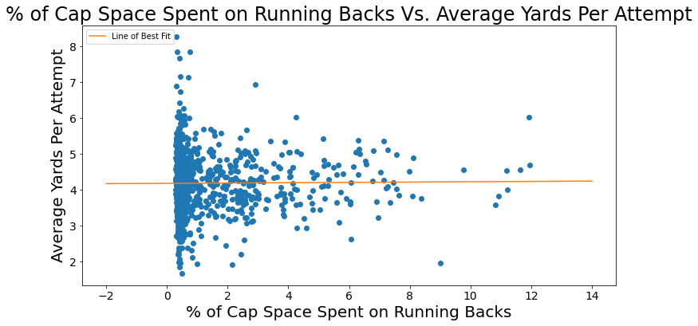

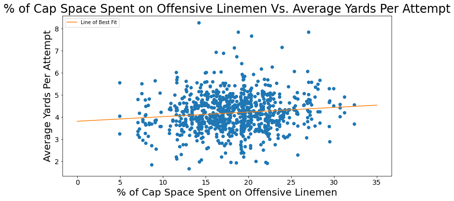

```python
X_rb, Y_rb = graph_with_line(rb_table, "cap %", "avg yards", "% of Cap Space Spent on Running Backs", "Average Yards Per Attempt")
X_line, Y_line = graph_with_line(rb_table, "line cap %", "avg yards", "% of Cap Space Spent on Offensive Linemen", "Average Yards Per Attempt")
```

It seems like there is a lot of noise around running backs with a low pay, this is likely because they may have around 20 runs which is a pretty small sample size and can lead to large variance in the average yards per attempt, before analyzing further we can use only running backs which have over a certain number of runs

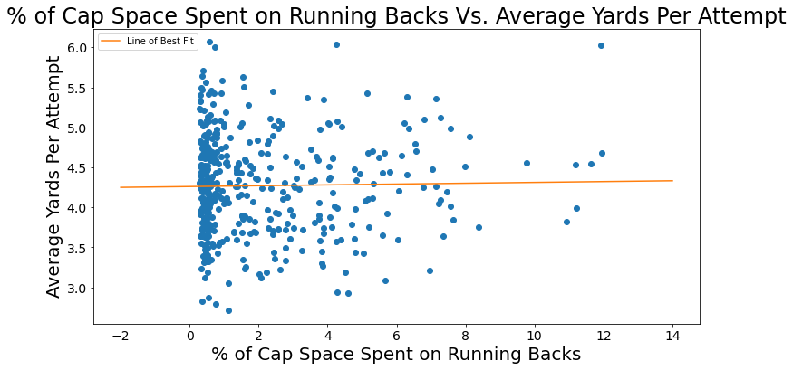

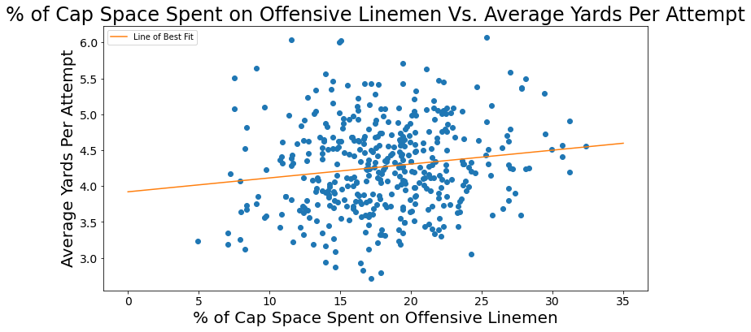

```python
# minimum number of runs
runs = 100

X_rb, Y_rb = graph_with_line(rb_table[rb_table["Runs"] >= 100], "cap %", "avg yards", "% of Cap Space Spent on Running Backs", "Average Yards Per Attempt")
X_line, Y_line = graph_with_line(rb_table[rb_table["Runs"] >= 100], "line cap %", "avg yards", "% of Cap Space Spent on Offensive Linemen", "Average Yards Per Attempt")
```

### Analysis of Average Yards Per Atttempt Vs. % of Cap Space Spent on Running Back/Offensive Line

```python
# run statistics tests on the linear regression model using statsmodel
print(sm.OLS(Y_rb, X_rb).fit().summary())
print(sm.OLS(Y_line, X_line).fit().summary())
```

```
                            OLS Regression Results
==============================================================================
Dep. Variable:                      y   R-squared:                       0.000
Model:                            OLS   Adj. R-squared:                 -0.002
Method:                 Least Squares   F-statistic:                    0.1495
Date:                Sun, 19 Dec 2021   Prob (F-statistic):              0.699
Time:                        20:41:38   Log-Likelihood:                -394.21
No. Observations:                 418   AIC:                             792.4
Df Residuals:                     416   BIC:                             800.5
Df Model:                           1
Covariance Type:            nonrobust
==============================================================================
                 coef    std err          t      P>|t|      [0.025      0.975]
------------------------------------------------------------------------------
const          4.2605      0.041    103.276      0.000       4.179       4.342
x1             0.0052      0.013      0.387      0.699      -0.021       0.032
==============================================================================
Omnibus:                        3.126   Durbin-Watson:                   1.414
Prob(Omnibus):                  0.210   Jarque-Bera (JB):                3.162
Skew:                           0.184   Prob(JB):                        0.206
Kurtosis:                       2.785   Cond. No.                         4.38
==============================================================================

Notes:
[1] Standard Errors assume that the covariance matrix of the errors is correctly specified.
                            OLS Regression Results
==============================================================================
Dep. Variable:                      y   R-squared:                       0.022
Model:                            OLS   Adj. R-squared:                  0.020
Method:                 Least Squares   F-statistic:                     9.467
Date:                Sun, 19 Dec 2021   Prob (F-statistic):            0.00223
Time:                        20:41:38   Log-Likelihood:                -389.59
No. Observations:                 418   AIC:                             783.2
Df Residuals:                     416   BIC:                             791.2
Df Model:                           1
Covariance Type:            nonrobust
==============================================================================
                 coef    std err          t      P>|t|      [0.025      0.975]
------------------------------------------------------------------------------
const          3.9206      0.118     33.253      0.000       3.689       4.152
x1             0.0193      0.006      3.077      0.002       0.007       0.032
==============================================================================
Omnibus:                        4.607   Durbin-Watson:                   1.437
Prob(Omnibus):                  0.100   Jarque-Bera (JB):                4.696
Skew:                           0.253   Prob(JB):                       0.0956
Kurtosis:                       2.884   Cond. No.                         73.7
==============================================================================

Notes:
[1] Standard Errors assume that the covariance matrix of the errors is correctly specified.
```

This time the results seems very much the opposite of last time, this time the offensive line seems to have much more effect on the run game. One possible explanation is that teams who are planning on running more often are more willing to spend more on running backs, that would explain why total rushing yards is correlated with running back pay while average yards per attempt does not seem to be correlated. This is only one possibility among many though. Looking at the p value for the lineman pay it seems to be significantly correlated with average yards per attempt, it still has a low R squared value though. This means that there are still a lot of other factors that go into the average yards per attempt. One thing that can still be messing up our average yards per attempt is outliers, must runs are short with few going over 10 yards. However every once in a while the running back gets away from the defense and can get a run 50 yards or more. These long runs can skew the average higher than it should be. Unfortunately there is no data on individual runs in the data we got so we can not try looking at the median.

### Investigating Advanced Statistics

The website Football Outsider that we got data from has many advanced statistics, some of these attempt to evaluate running backs and offensive lines individually. The two we will look at are [Defense-Adjusted Yards Above Replacement (DYAR)](https://www.footballoutsiders.com/info/methods#dyar) for the running backs and [adjusted line yards](https://www.footballoutsiders.com/info/methods#ALY) for the offensive lines. If these statistics work like intended then we would expect them to be more correlated to pay than average yards per attempt. To see if this is true we can graph them.

```python
# join the running back pay and stats tables
team_table = pd.merge(team_table, line_stats_table[["Team", "year", "Adj. Line  Yards"]].rename(columns={'Team': 'team'}), how='inner', on=['year', 'team'])
```

```python
rb_table
```

|  | Player | team | DYAR | YAR | DVOA | VOA | Runs | Yards | EYds | TD | FUM | Suc Rate | year | POS | cap % | line cap % | avg yards |
| --- | --- | --- | --- | --- | --- | --- | --- | --- | --- | --- | --- | --- | --- | --- | --- | --- | --- |
| 0 | L. McCoy | PHI | 304 | 262 | 15.8% | 12.4% | 273 | 1309 | 1564 | 17 | 1 | 51% | 2011 | RB | 0.73 | 22.43 | 4.794872 |
| 1 | D. Lewis | PHI | 25 | 23 | 18.3% | 16.1% | 23 | 102 | 119 | 1 | 0 | NaN | 2011 | RB | 0.46 | 22.43 | 4.434783 |
| 2 | R. Brown | PHI | -12 | -26 | -14.9% | -22.3% | 42 | 136 | 141 | 1 | 1 | NaN | 2011 | RB | 1.04 | 22.43 | 3.238095 |
| 3 | M. Lynch | SEA | 201 | 159 | 8.9% | 5.2% | 285 | 1204 | 1317 | 12 | 3 | 46% | 2011 | RB | 3.17 | 18.02 | 4.224561 |
| 4 | L. Washington | SEA | -1 | 0 | -9.1% | -8.6% | 53 | 248 | 164 | 1 | 0 | NaN | 2011 | RB | 2.60 | 18.02 | 4.679245 |
| ... | ... | ... | ... | ... | ... | ... | ... | ... | ... | ... | ... | ... | ... | ... | ... | ... | ... |
| 839 | T. Johnson | NYJ | 8 | 45 | -5.0% | 10.5% | 54 | 254 | 216 | 1 | 0 | NaN | 2020 | RB | 0.34 | 19.55 | 4.703704 |
| 840 | L. Perine | NYJ | -6 | 11 | -10.7% | -4.7% | 64 | 232 | 242 | 2 | 0 | NaN | 2020 | RB | 0.51 | 19.55 | 3.625000 |
| 841 | J. Jacobs | LV | -54 | 24 | -12.9% | -6.6% | 273 | 1065 | 972 | 12 | 2 | 51% | 2020 | RB | 1.51 | 27.33 | 3.901099 |
| 842 | J. Richard | LV | 46 | 30 | 46.8% | 27.5% | 22 | 123 | 142 | 1 | 1 | NaN | 2020 | RB | 1.77 | 27.33 | 5.590909 |
| 843 | D. Booker | LV | 26 | 40 | -1.8% | 1.7% | 93 | 423 | 378 | 3 | 1 | NaN | 2020 | RB | 0.53 | 27.33 | 4.548387 |

844 rows × 17 columns

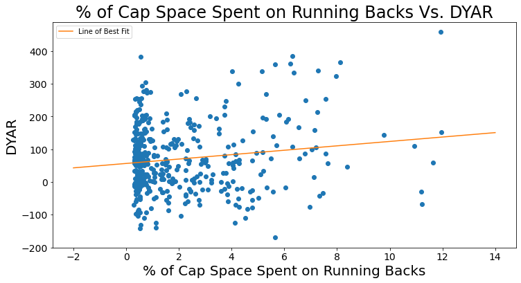

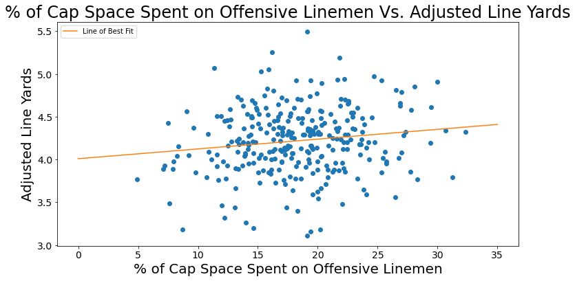

```python
X_rb, Y_rb = graph_with_line(rb_table[rb_table["Runs"] >= 100], "cap %", "DYAR", "% of Cap Space Spent on Running Backs", "DYAR")
X_line, Y_line = graph_with_line(team_table, "line cap %", "Adj. Line  Yards", "% of Cap Space Spent on Offensive Linemen", "Adjusted Line Yards")
```

```python
# run statistics tests on the linear regression model using statsmodel
print(sm.OLS(Y_rb, X_rb).fit().summary())
print(sm.OLS(Y_line, X_line).fit().summary())
```

```
                            OLS Regression Results
==============================================================================
Dep. Variable:                      y   R-squared:                       0.022
Model:                            OLS   Adj. R-squared:                  0.019
Method:                 Least Squares   F-statistic:                     9.253
Date:                Sun, 19 Dec 2021   Prob (F-statistic):            0.00250
Time:                        20:41:39   Log-Likelihood:                -2528.7
No. Observations:                 418   AIC:                             5061.
Df Residuals:                     416   BIC:                             5069.
Df Model:                           1
Covariance Type:            nonrobust
==============================================================================
                 coef    std err          t      P>|t|      [0.025      0.975]
------------------------------------------------------------------------------
const         56.7206      6.810      8.329      0.000      43.334      70.107
x1             6.7305      2.213      3.042      0.002       2.381      11.080
==============================================================================
Omnibus:                       16.593   Durbin-Watson:                   1.127
Prob(Omnibus):                  0.000   Jarque-Bera (JB):               17.655
Skew:                           0.501   Prob(JB):                     0.000147
Kurtosis:                       3.091   Cond. No.                         4.38
==============================================================================

Notes:
[1] Standard Errors assume that the covariance matrix of the errors is correctly specified.
                            OLS Regression Results
==============================================================================
Dep. Variable:                      y   R-squared:                       0.020
Model:                            OLS   Adj. R-squared:                  0.017
Method:                 Least Squares   F-statistic:                     6.237
Date:                Sun, 19 Dec 2021   Prob (F-statistic):             0.0131
Time:                        20:41:39   Log-Likelihood:                -133.87
No. Observations:                 300   AIC:                             271.7
Df Residuals:                     298   BIC:                             279.1
Df Model:                           1
Covariance Type:            nonrobust
==============================================================================
                 coef    std err          t      P>|t|      [0.025      0.975]
------------------------------------------------------------------------------
const          4.0088      0.087     46.301      0.000       3.838       4.179
x1             0.0114      0.005      2.497      0.013       0.002       0.020
==============================================================================
Omnibus:                        3.443   Durbin-Watson:                   1.337
Prob(Omnibus):                  0.179   Jarque-Bera (JB):                3.723
Skew:                          -0.100   Prob(JB):                        0.155
Kurtosis:                       3.508   Cond. No.                         75.0
==============================================================================

Notes:
[1] Standard Errors assume that the covariance matrix of the errors is correctly specified.
```

The correlation between running back pay and DYAR is much stronger than with average yards per attempt. That means this statistic is likely doing a good job for what it was intended to do. The correlation between offensive line pay and adjusted line yards is very similar to with average yards per attempt. That means that this stat isn't really doing a good job of capturing the performance on the offensive line independent of the running back.

### Concluding Importance of Running Backs Vs. Offensive Line

One thing that is clear is that there a lot of factors that go into how well a teams run game will be on a given year. Exactly how much is due to the skill of running backs or the offensive line is hard to tell, both because it is hard to measure their individual skill in the first place and also because there is a lot that goes into how well the run game is. The results we've seen seem to indicate that the skill of the offensive line has more impact but it is far from conclusive. For evaluating them individually with stats, the DYAR stat from Football Outsider seems to do a good job for running backs, while evaluating the offensive lines still needs some better solutions.

## Predictive Model

### Fantasy Football

Fantasy football is a game that people play where you have to choose players from the NFL you think will perform well to put on your team, if you aren't familiar with the game you can read more here). In fantasy football one of the positions that is included is running backs. Running backs score points based on how many rushing yards they get. So being able to predict that before a season will lead to choosing better running backs. Looking at stats from previous years can give a good idea to potential performance. But in scenarios where a good running back is switching teams and you want to know if they will still do good with a new offensive line you can't rely too much on just looking at how many yards they had the previous year. To create an aid to help in that situation we will create a Nearest Neighbor Regressor in order to predict the performance of a running back paired with a particular offensive line.

### k-NN Regressor

We will use the [k-NN regressor implemented in the machine learning library scikit-learn](https://scikit-learn.org/stable/modules/generated/sklearn.neighbors.KNeighborsRegressor.html) to make our model. As input we will use the pay for a running back and their offensive line and also the DYAR. Since DYAR is based on the stats from a season we need to use the DYAR from the previous seasons or else we wouldn't be able to predict anything. We will try to predict the number of yards the running back will have over the season. First we need to prepare out training data.

#### Training Data

```python
# create a table with DYAR values from the year before
temp = rb_table[["DYAR", "year", "team", "Player"]]
temp["year"] = temp["year"] + 1
temp.rename(columns={"DYAR": "DYAR last"}, inplace=True)

# get the data and labels from the running back table
examples = pd.merge(rb_table, temp, how='inner', on=['year', 'team', 'Player'])[["cap %", "line cap %", "DYAR last", "Yards"]]
data = examples[["cap %", "line cap %", "DYAR last"]]
labels = examples[["Yards"]]

# split up the data into training data and holdout data
training_data, holdout_data, training_labels, holdout_labels = train_test_split(data, labels, test_size = 0.20)

# further split the training data up into training data and validation data
training_data, validation_data, training_labels, validation_labels = train_test_split(training_data, training_labels, test_size = 0.125)
```

#### Hyperparameters

The two hyperparameters we will try to tune are the number of neighbors included in the model and whether or not the value oof distant neighbors are weighted lower, we will try from 1 to 299 neighbors and both options of weights for each of these. The resulting model will then be tested on the validation set each time to see which combination performs the best. We will evaluate how well one performs using mean squared error.

```python
# number of different amounts of neighbors to try
n = 299

# keep track of the best model and its hyperparameters
best_kNN = None
min_error = -1
n_neighbors = 0
weights = ''
error_list = []

# generate a model for each combination of hyperparameters
for w in ['uniform', 'distance']:
    for i in range(1,n+1):

        # load a kNN Regressor from scikit-learn
        kNN = KNeighborsRegressor(n_neighbors=i, weights=w)

        # train the model using our training data and training labels
        kNN.fit(training_data, training_labels)

        # predict the validation data with the model
        predicted_labels = kNN.predict(validation_data)

        # check the error of the model
        error = metrics.mean_squared_error(validation_labels, predicted_labels)
        error_list.append(error)

        # save the model if it has performed the best so far
        if min_error == -1:
            min_error = error
        if error < min_error:
            min_error = error
            n_neighbors = i
            weights = w
            best_kNN = kNN
```

Now we can look at the error of the models as the number of neighbors increased

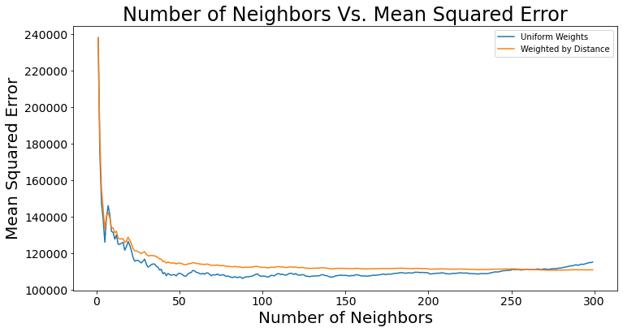

```python
# set up the aesthetics, title, and labels for the graph
fig= pyplot.figure(figsize=(12,6))
pyplot.xticks(fontsize=14)
pyplot.xlabel("Number of Neighbors", fontsize=20)
pyplot.yticks(fontsize=14)
pyplot.ylabel("Mean Squared Error", fontsize=20)
pyplot.title("Number of Neighbors Vs. Mean Squared Error", fontsize=24)

# number of neighbors vs mean squared error
pyplot.plot(range(1,n+1), error_list[0:n], label="Uniform Weights")
pyplot.plot(range(1,n+1), error_list[n:n*2], label="Weighted by Distance")
pyplot.legend(loc="upper right")

pass
```

```python
print("The best performing model had " + str(n_neighbors) + " neighbors and used the " + weights + " weights")
```

```
The best performing model had 88 neighbors and used the uniform weights
```

```python
# predict the validation data with the model
predicted_labels = kNN.predict(holdout_data)

# check the error of the model
error = metrics.mean_squared_error(holdout_labels, predicted_labels)

print("The mean squared error is " + str(error))
print("converted back into the units of yards that is " + str(error ** (1/2)) + " yards")
```

```
The mean squared error is 119355.03583933292
converted back into the units of yards that is 345.47798169975016 yards
```

This is a pretty high error, there are a lot of factors that this model does not take into consideration so it can not predict with very much accuracy. If we look at the variance of the data we can see that it is doing a little better than just guessing though.

```python
print("The holdout varience is " + str(int(holdout_labels.var())))
print("converted back into the units of yards that is " + str(int(holdout_labels.var()) ** (1/2)) + " yards")
```

```
The holdout varience is 142808
converted back into the units of yards that is 377.8994575280573 yards
```

While this model was not very accurate using the data we had it can still be one thing to be taken into consideration when selecting a running back for fantasy football.

## Conclusion

Predicting football statistics is complicated. This is easy to see by the fact that many experts have wildly different opinions about what will happen before each season. In order to further strengthen the predictive model we created it would be interesting to see what additional data could be used to help. It will certainly never very accurate but the better it can be the more useful it could become. In looking into the impact of running backs and offensive lines on the run game we needed to scrape data from a variety of sources then use techniques to clean and combine this data so that we could use it together. We then created visualizations and used statistical tests to draw conclusions from the data. We also used machine learning to create a predictive model using the statistics we had identified in the previous analysis.

If you are interested in football stats then there is plenty more to look at, we only investigating runs in this tutorial which is only one small part of the game, There are plenty of other positions and stats to look at and draw conclusions from.